# Sensory Data

G. Fitton

2024-01-05

## Session

### Repositories

#### Report

The source code for the analysis

https://github.com/jobs-george/sensory-data

with the R markdown hosted here

https://jobs-george.github.io/

#### Webapp

The source code for the visualization app

https://github.com/jobs-george/sensory-data-app

A live demo of the app

https://jobs-george.shinyapps.io/sensory-data-app/

### Session Info

```r
sessionInfo()$R.version$version.string
```

```
## [1] "R version 4.3.2 (2023-10-31)"
```

```r
sessionInfo()$platform
```

```
## [1] "x86_64-pc-linux-gnu (64-bit)"
```

## Data

### Read File

Reading the file and inspecting the data shows the file contains time series data linked to several categorical variables (devices, states, …). The data is in “long format” with the value column containing a mixture of logical, categorical, and numerical values.

```r
df <- readr::read_csv(file.path("data", "test_ukdri_crt_110722.csv"))
head(df)
```

| patient_id | start_date | device_type | source | unit | value |
| --- | --- | --- | --- | --- | --- |
| 6xrbQMkh12eYMdP7Xi1ggc | 2022-01-29 13:30:55 | pir | Bedroom | \\ms | True |
| 6xrbQMkh12eYMdP7Xi1ggc | 2022-01-29 13:32:30 | pir | Bedroom | \\ms | True |
| 6xrbQMkh12eYMdP7Xi1ggc | 2022-01-29 13:33:55 | pir | Bedroom | \\ms | True |
| 6xrbQMkh12eYMdP7Xi1ggc | 2022-01-29 13:34:34 | pir | Bedroom | \\ms | True |
| 6xrbQMkh12eYMdP7Xi1ggc | 2022-01-29 13:35:06 | pir | Bedroom | \\ms | True |
| 6xrbQMkh12eYMdP7Xi1ggc | 2022-01-29 13:39:38 | pir | Bedroom | \\ms | True |

### Data Quality

The data contains 3 duplicates

```r
sum(duplicated(df))
```

```
## [1] 3
```

which are removed

```r
df <- df[!duplicated(df), ]
```

Check column types (`value` is mixed numeric / categorical)

```r
lapply(df, class)
```

```
## $patient_id
## [1] "character"
##
## $start_date
## [1] "POSIXct" "POSIXt"
##
## $device_type
## [1] "character"
##
## $source
## [1] "character"
##
## $unit
## [1] "character"
##
## $value
## [1] "character"
```

### Data Structure

Inspection of the unique combinations of the categorical variables shows the data is a collection of devices that have one or many measurements with potentially different units.

```r
df_structure <- unique(df[, c("device_type", "unit", "source")]) %>% arrange(device_type)
df_structure
```

| device_type | unit | source |
| --- | --- | --- |
| Electronic_sphygmomanometer | /min | raw_heart_rate |
| Electronic_sphygmomanometer | mm[Hg] | systolic_bp |
| Electronic_sphygmomanometer | mm[Hg] | diastolic_bp |
| Health_watch | /min | raw_heart_rate |
| Health_watch | % | raw_oxygen_saturation |
| Pulse_oximeter | /min | raw_heart_rate |
| Pulse_oximeter | % | raw_oxygen_saturation |
| Scale | kg | raw_body_weight |
| Scale | % | raw_total_body_fat |
| Scale | kg | raw_total_body_fat |

[output cut: 19 more lines]

More precisely, between 2 and 7 measurements across the ranges of devices

```r
df_structure %>%
  group_by(device_type) %>%
  summarise(ncount = n()) %>%
  arrange(ncount)
```

| device_type | ncount |
| --- | --- |
| Health_watch | 2 |
| Pulse_oximeter | 2 |
| Thermometer,_Forehead_thermometer | 2 |
| door | 2 |
| Electronic_sphygmomanometer | 3 |
| pir | 5 |
| bed_mat | 6 |
| Scale | 7 |

Since this is a time series dataset we inspect the time structure of each device and its measurements. Analyzing the minimum and maximum dates we see that the data are recorded between the end of January 2022 and the end of February 2022 with small differences between start and end dates of measurements. (Note, we assume the variable `start_date` corresponds to the *time of measurement*).

```r
df %>%
  group_by(device_type) %>%
  summarise(
    date_min = min(start_date),
    date_max = max(start_date)) %>%
  arrange(date_min)
```

| device_type | date_min | date_max |
| --- | --- | --- |
| pir | 2022-01-29 13:30:55 | 2022-02-28 23:57:33 |
| door | 2022-01-29 13:35:35 | 2022-02-28 22:56:17 |
| bed_mat | 2022-01-29 18:04:00 | 2022-03-01 00:00:00 |
| Health_watch | 2022-01-30 07:46:10 | 2022-02-28 16:15:35 |
| Scale | 2022-01-30 07:56:35 | 2022-02-28 20:59:29 |
| Thermometer,_Forehead_thermometer | 2022-01-30 08:17:12 | 2022-02-28 20:57:31 |
| Pulse_oximeter | 2022-01-30 08:17:46 | 2022-02-28 20:57:12 |
| Electronic_sphygmomanometer | 2022-01-30 08:19:00 | 2022-02-28 20:57:58 |

And also check that some *replicates* overlap.

```r
df %>%
  group_by(patient_id) %>%
  summarise(
    date_min = min(start_date),
    date_max = max(start_date)) %>%
  arrange(date_min)
```

| patient_id | date_min | date_max |
| --- | --- | --- |
| 6xrbQMkh12eYMdP7Xi1ggc | 2022-01-29 13:30:55 | 2022-03-01 00:00:00 |
| PtSJCv5bDWvZe3f1V7wRgQ | 2022-01-29 13:32:15 | 2022-03-01 00:00:00 |
| VmrLbcBzyzacPx8WBnnttf | 2022-01-29 13:32:21 | 2022-03-01 00:00:00 |
| JQwQLzfRYX5KmetFSg69kK | 2022-01-29 13:35:38 | 2022-02-28 10:15:14 |
| R8amTSvAQkobnkeuWybkWL | 2022-01-29 13:37:22 | 2022-03-01 00:00:00 |
| EzjmQuxceJzLATdtyUbDn8 | 2022-01-29 13:38:42 | 2022-02-28 22:06:50 |
| WtYLx1dEr6hHgQDg8TKcGP | 2022-01-29 13:39:17 | 2022-03-01 00:00:00 |
| JHvi2gBhcufYzhmg4F1H9T | 2022-01-29 13:39:59 | 2022-02-28 23:27:57 |
| BjAJmKMnmScXNFfSGd5RWr | 2022-01-29 13:42:01 | 2022-02-28 23:52:32 |
| Hpbmfij5E6hh19u1uKFXQT | 2022-01-29 13:45:33 | 2022-03-01 00:00:00 |

Finally, we inspect the data resolution and heterogeneity, i.e., are the same number of devices used per patient and is the data recorded at the same times for each device and at *regular times*. Since each device potentially measures at different points in time. (Note, the `unit` column corresponds to the unit of the measurement in `value`, not the unit of the time resolution.)

[output not shown]

| patient_id | device_type | source | unit | ncount |
| --- | --- | --- | --- | --- |
| 6xrbQMkh12eYMdP7Xi1ggc | Pulse_oximeter | raw_heart_rate | /min | 6 |
| 6xrbQMkh12eYMdP7Xi1ggc | Pulse_oximeter | raw_oxygen_saturation | % | 6 |
| 6xrbQMkh12eYMdP7Xi1ggc | Thermometer,_Forehead_thermometer | raw_body_temperature | Cel | 3 |
| 6xrbQMkh12eYMdP7Xi1ggc | Thermometer,_Forehead_thermometer | raw_skin_temperature | Cel | 3 |
| 6xrbQMkh12eYMdP7Xi1ggc | bed_mat | Bed_in | \\min | 19 |
| 6xrbQMkh12eYMdP7Xi1ggc | bed_mat | Bed_out | \\min | 18 |
| 6xrbQMkh12eYMdP7Xi1ggc | bed_mat | heart_rate | \\min | 4059 |
| 6xrbQMkh12eYMdP7Xi1ggc | bed_mat | respiratory_rate | \\min | 4059 |
| 6xrbQMkh12eYMdP7Xi1ggc | bed_mat | snoring | \\min | 4059 |
| 6xrbQMkh12eYMdP7Xi1ggc | bed_mat | state | \\min | 4059 |

[output cut: 177 more lines]

## Visualization

It can often help to interactively inspect the data. An RShiny Webapp has been created for this purpose and is published here

https://jobs-george.shinyapps.io/sensory-data-app/

## Analysis

### Research Question

Before doing any analysis we need a research question to answer! Since no explicit question has been set, we can make up a few questions for fun…

Note, the last question we aren’t going to try to answer in such a short amount of time, but it helps with the context of the assessment.

### 1. Comparison of GP Signals

Gaussian processes for regression[^1] are useful for unevenly spaced data so we will use them to compare the time series of the same quantity measured heterogeneously by two different devices.

Reducing the full dataset into a sample across the devices that measure heart rate shows large differences between samples sizes across both patient and device.

```r
heart_rate_devices <- c("Health_watch",
                        "Pulse_oximeter",
                        "Electronic_sphygmomanometer")

df_data <- df %>%
  filter(device_type %in% heart_rate_devices) %>%
  filter(source == "raw_heart_rate")

# set column type
df_data$value <- as.numeric(df_data$value)

# check the resolution of each series
df_data %>%
  group_by(patient_id, device_type) %>%
  summarise(ncount = n(),
            date_min = min(start_date),
            date_max = max(start_date)) %>%
  arrange(patient_id)
```

| patient_id | device_type | ncount | date_min | date_max |
| --- | --- | --- | --- | --- |
| 6xrbQMkh12eYMdP7Xi1ggc | Pulse_oximeter | 6 | 2022-02-01 11:20:43 | 2022-02-22 16:02:24 |
| BjAJmKMnmScXNFfSGd5RWr | Electronic_sphygmomanometer | 9 | 2022-02-03 12:30:08 | 2022-02-03 13:42:42 |
| EzjmQuxceJzLATdtyUbDn8 | Electronic_sphygmomanometer | 8 | 2022-02-12 11:26:00 | 2022-02-23 19:46:00 |
| Hpbmfij5E6hh19u1uKFXQT | Electronic_sphygmomanometer | 49 | 2022-01-30 08:19:00 | 2022-02-28 09:23:00 |
| Hpbmfij5E6hh19u1uKFXQT | Pulse_oximeter | 30 | 2022-01-30 08:17:46 | 2022-02-28 09:11:23 |
| PtSJCv5bDWvZe3f1V7wRgQ | Electronic_sphygmomanometer | 42 | 2022-01-30 19:19:00 | 2022-02-28 08:53:00 |
| PtSJCv5bDWvZe3f1V7wRgQ | Pulse_oximeter | 28 | 2022-01-30 19:22:16 | 2022-02-28 08:48:46 |
| R8amTSvAQkobnkeuWybkWL | Electronic_sphygmomanometer | 5 | 2022-02-02 07:45:07 | 2022-02-28 20:57:58 |
| R8amTSvAQkobnkeuWybkWL | Health_watch | 5419 | 2022-01-30 08:07:33 | 2022-02-23 21:26:23 |
| R8amTSvAQkobnkeuWybkWL | Pulse_oximeter | 7 | 2022-02-03 12:20:44 | 2022-02-28 20:57:12 |

[output cut: 4 more lines]

We restrict the analysis to patient `Hpbmfij5E6hh19u1uKFXQT` for illustrative purposes, where given two signals measured at different points in time, we generate predictions of trajectories for comparison.

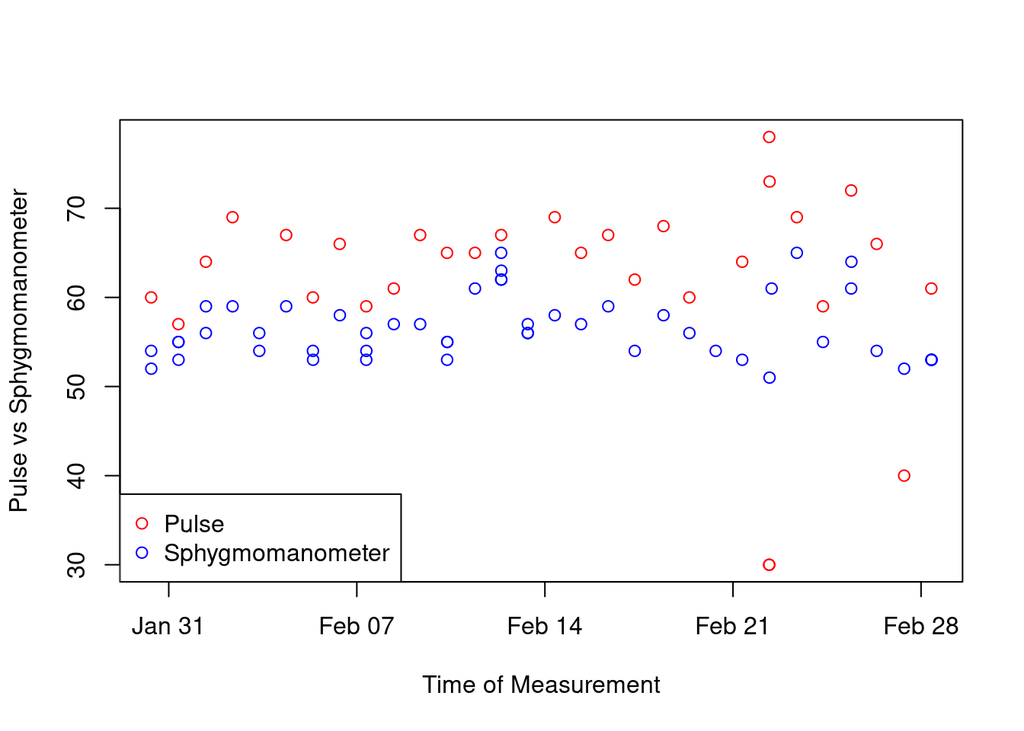

```r
df_pulse <- df_data %>%
  filter(patient_id == "Hpbmfij5E6hh19u1uKFXQT") %>%
  filter(device_type == "Pulse_oximeter")

df_sphyg <- df_data %>%
  filter(patient_id == "Hpbmfij5E6hh19u1uKFXQT") %>%
  filter(device_type == "Electronic_sphygmomanometer")

plot(
  df_pulse$start_date,
  df_pulse$value,
  col = "red",
  ylab = "Pulse vs Sphygmomanometer",
  xlab = "Time of Measurement")

points(df_sphyg$start_date, df_sphyg$value, col = "blue")

legend(
  x = "bottomleft",
  legend = c("Pulse", "Sphygmomanometer"),
  pch = 1,
  col = c("red", "blue"))
```

Calculating the difference between these two signals or incorporating information from them both can be tricky given their irregular spacing and difference in sample size.

Gaussian processes are a general-purpose non-parametric regression tool that can be useful for fitting data without needing to make prior assumptions about the expected shape of the trajectory.

There are many packages available, we will use the *mgpr* package because it provides a fairly high-level interface and therefore not too much code.

```r
# remotes::install_github("pvarvia/mgpr")
library(mgpr)
```

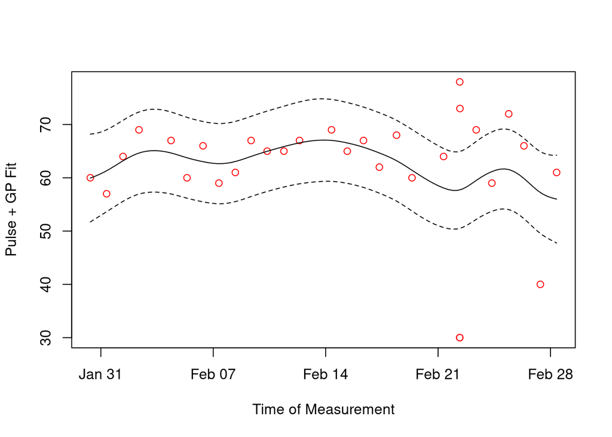

```r
source(file.path("src", "gpr.R"))

params <- list(sigma = 1,
               corlen = 1,
               errorvar = 0.1)

list_results_pulse <-
  gpr(datay = as.numeric(df_pulse$value),
      datax = as.numeric(df_pulse$start_date),
      params = params)

plot(
  df_pulse$start_date,
  df_pulse$value,
  col = "red",
  ylab = "Pulse + GP Fit",
  xlab = "Time of Measurement")

lines(as_datetime(list_results_pulse$xhatr), list_results_pulse$predr)
lines(as_datetime(list_results_pulse$xhatr), list_results_pulse$lower, lty = 2)
lines(as_datetime(list_results_pulse$xhatr), list_results_pulse$upper, lty = 2)
```

Using the same method for the second device and comparing the difference in medians generates the following plot.

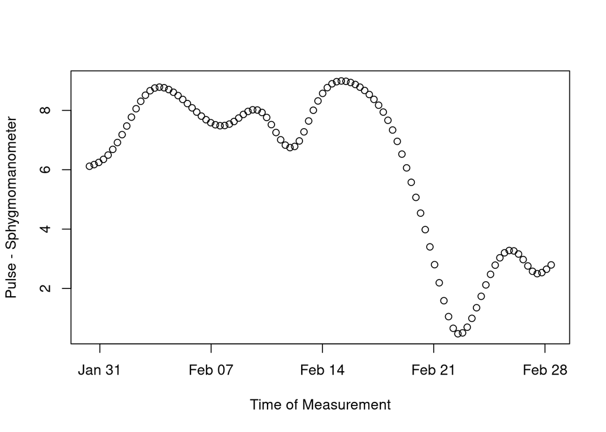

```r
list_results_sphyg <-
  gpr(datay = as.numeric(df_sphyg$value),
      datax = as.numeric(df_sphyg$start_date),
      params = params)

delta <- list_results_pulse$predr - list_results_sphyg$predr

plot(
  as_datetime(list_results_sphyg$xhatr),
  delta,
  ylab = "Pulse - Sphygmomanometer",
  xlab = "Time of Measurement")
```

Future directions:

- Extend uni-variate to multivariate across more response variables
- Combine Gaussian processes in [stan](https://mc-stan.org/docs/stan-users-guide/gaussian-processes.html) with a larger hierarchical Bayesian model applied across the full dataset

### 2. Linear Regression

We use the `pir` device to answer question 2, which we assume stands for *passive infrared sensor*, and measures the location of the patient in the house. We will try to see if we can predict a person’s state given their location in the house.

The following code block generates a PIR-state dataset.

```r
df_pir <- df %>%
  filter(device_type == "pir")

df_state <- df %>%
  filter(source == "state")

cols_state <- c("patient_id", "start_date", "value")
cols_join <- c("patient_id", "start_date")
cols_pir <- c("patient_id", "start_date", "source")

df_pir_state <-
  inner_join(df_pir[, cols_pir],
             df_state[, cols_state],
             by = cols_join)

df_pir_state$patient_id <- as.factor(df_pir_state$patient_id)
df_pir_state$source <- as.factor(df_pir_state$source)
df_pir_state$value <- as.factor(df_pir_state$value)

df_pir_state
```

| patient_id | start_date | source | value |
| --- | --- | --- | --- |
| 6xrbQMkh12eYMdP7Xi1ggc | 2022-02-22 22:53:00 | Hallway | DEEP |
| 6xrbQMkh12eYMdP7Xi1ggc | 2022-02-23 02:27:00 | Bathroom | LIGHT |
| 6xrbQMkh12eYMdP7Xi1ggc | 2022-02-23 22:39:00 | Hallway | AWAKE |
| 6xrbQMkh12eYMdP7Xi1ggc | 2022-02-23 22:47:00 | Kitchen | AWAKE |
| 6xrbQMkh12eYMdP7Xi1ggc | 2022-02-23 23:02:00 | Hallway | AWAKE |
| 6xrbQMkh12eYMdP7Xi1ggc | 2022-02-24 22:47:00 | Hallway | AWAKE |
| 6xrbQMkh12eYMdP7Xi1ggc | 2022-02-24 23:26:00 | Hallway | DEEP |
| 6xrbQMkh12eYMdP7Xi1ggc | 2022-02-25 08:04:00 | Lounge | LIGHT |
| 6xrbQMkh12eYMdP7Xi1ggc | 2022-02-25 21:28:00 | Lounge | DEEP |
| 6xrbQMkh12eYMdP7Xi1ggc | 2022-02-25 22:00:00 | Lounge | DEEP |

[output cut: 146 more lines]

We map each state to a numerical value, increasing with the stage of the person’s sleep (not explicitly ordinal).

```r
df_pir_state$response <- as.character(df_pir_state$value)

df_pir_state$response[df_pir_state$response == "AWAKE"] <- 1
df_pir_state$response[df_pir_state$response == "LIGHT"] <- 2
df_pir_state$response[df_pir_state$response == "DEEP"]  <- 3
df_pir_state$response[df_pir_state$response == "REM"]   <- 4
```

Next we use a linear regression to analyze the relationship between the state of the person and the person’s location in the house.

```r
fit1 <- stats::lm(
  formula = response ~ source,
  data = df_pir_state)
base::summary(fit1)
```

```
##
## Call:
## stats::lm(formula = response ~ source, data = df_pir_state)
##
## Residuals:
##     Min      1Q  Median      3Q     Max
## -1.1177 -0.6071 -0.1177  0.3929  2.4146
##
## Coefficients:
##               Estimate Std. Error t value Pr(>|t|)
## (Intercept)    1.60714    0.13965  11.508   <2e-16 ***
## sourceBedroom  0.04402    0.17945   0.245   0.8066
## sourceHallway  0.02249    0.19932   0.113   0.9103
## sourceKitchen -0.02178    0.18117  -0.120   0.9045
## sourceLounge   0.51050    0.22721   2.247   0.0261 *
## ---
## Signif. codes:  0 '***' 0.001 '**' 0.01 '*' 0.05 '.' 0.1 ' ' 1
##
## Residual standard error: 0.739 on 151 degrees of freedom
## Multiple R-squared:  0.04481,    Adjusted R-squared:  0.01951
## F-statistic: 1.771 on 4 and 151 DF,  p-value: 0.1375
```

```r
fit2 <- stats::lm(
  formula = response ~ source + patient_id,
  data = df_pir_state)

base::summary(fit2)
```

```
##
## Call:
## stats::lm(formula = response ~ source + patient_id, data = df_pir_state)
##
## Residuals:
##      Min       1Q   Median       3Q      Max
## -1.07314 -0.44303 -0.07314  0.33008  2.30488
##
## Coefficients:
##                                   Estimate Std. Error t value Pr(>|t|)
## (Intercept)                       2.135083   0.220580   9.679  < 2e-16 ***
## sourceBedroom                    -0.208133   0.180173  -1.155 0.249929
## sourceHallway                    -0.061947   0.205998  -0.301 0.764065
## sourceKitchen                    -0.151288   0.178080  -0.850 0.396984
## sourceLounge                      0.384953   0.231198   1.665 0.098080 .
## patient_idBjAJmKMnmScXNFfSGd5RWr -0.231826   0.254957  -0.909 0.364724
## patient_idEzjmQuxceJzLATdtyUbDn8 -0.711337   0.200653  -3.545 0.000530 ***
## patient_idHpbmfij5E6hh19u1uKFXQT -0.003189   0.228739  -0.014 0.988897
## patient_idPtSJCv5bDWvZe3f1V7wRgQ -0.031017   0.520751  -0.060 0.952587
## patient_idR8amTSvAQkobnkeuWybkWL -0.997282   0.278941  -3.575 0.000477 ***
## patient_idVmrLbcBzyzacPx8WBnnttf -0.540763   0.221211  -2.445 0.015711 *
## patient_idWtYLx1dEr6hHgQDg8TKcGP -0.610738   0.230600  -2.648 0.008988 **
## ---
## Signif. codes:  0 '***' 0.001 '**' 0.01 '*' 0.05 '.' 0.1 ' ' 1
##
## Residual standard error: 0.6784 on 144 degrees of freedom
## Multiple R-squared:  0.2324, Adjusted R-squared:  0.1737
## F-statistic: 3.962 on 11 and 144 DF,  p-value: 4.837e-05
```

Future directions:

- Linear regression is quite crude and more sophisticated analyses now exist like Generalized Linear Models (in frequentist and Bayesian settings) and a plethora of Machine Learning approaches, e.g., classification for the sleepy and awake patients

### 3. Respiratory Rate Distributions

In this final analysis we look at the distributions of respiration rates across patients. In the following block we extract the mean and standard deviation of respiration rates per patient.

```r
df_resp <- df %>%
  filter(source == "respiratory_rate")

df_resp <- df_resp[order(df_resp$patient_id, df_resp$start_date),]
df_resp$value <- as.numeric(df_resp$value)

df_resp %>%
  group_by(patient_id) %>%
  summarise(mean(value),
            sd(value))
```

| patient_id | mean(value) | sd(value) |
| --- | --- | --- |
| 6xrbQMkh12eYMdP7Xi1ggc | 12.73639 | 2.265516 |
| BjAJmKMnmScXNFfSGd5RWr | 13.10921 | 1.615636 |
| EzjmQuxceJzLATdtyUbDn8 | 16.30380 | 2.869687 |
| Hpbmfij5E6hh19u1uKFXQT | 15.28636 | 1.579759 |
| PtSJCv5bDWvZe3f1V7wRgQ | 15.63778 | 1.647975 |
| R8amTSvAQkobnkeuWybkWL | 13.16000 | 1.806121 |
| VmrLbcBzyzacPx8WBnnttf | 13.51689 | 1.846031 |
| WtYLx1dEr6hHgQDg8TKcGP | 13.82485 | 1.882903 |

The next code block plots the distribution of rates across the patients and in time. Again, it’s quite surprising to see such a large range of rates in such small sample.

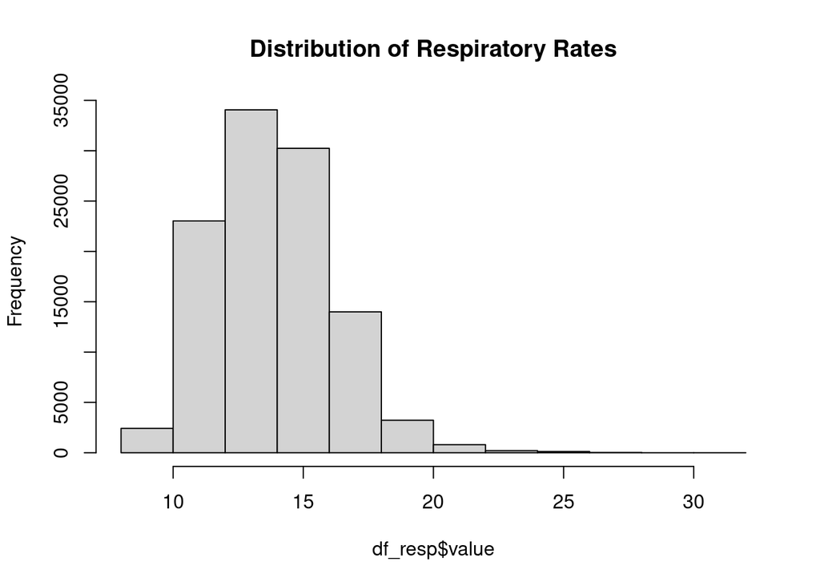

```r
hist(
  df_resp$value,
  breaks = 15,
  main = "Distribution of Respiratory Rates")
```

Future directions:

- A toolbox of analyses and metrics that combine information from different sources would be useful to *connect* measurements
- Can we predict respiration rates given some other information? Or does a significantly high respiration rate indicate some other condition that can be detected elsewhere in the data?

## Conclusions

With only a few simple analyses a key theme already reoccurs in the (sub-)conclusions of each section - what is the context behind the data collection? How was the data collected and why is it so heterogeneous? Data analysis without context, i.e., without working closely with the experimental team can lead to very spurious inferences. Data quality procedures and sense-checks can only take a data analysis so far. Close collaboration with the data collection teams provides essential context for the data analyst.

## Appendix

### Heart Rate Across Devices

```r
unique(df[, c("device_type", "unit", "source")]) %>% arrange(source)
```

| device_type | unit | source |
| --- | --- | --- |
| door | \\ms | Back door |
| pir | \\ms | Bathroom |
| bed_mat | \\min | Bed_in |
| bed_mat | \\min | Bed_out |
| pir | \\ms | Bedroom |
| door | \\ms | Front door |
| pir | \\ms | Hallway |
| pir | \\ms | Kitchen |
| pir | \\ms | Lounge |
| Electronic_sphygmomanometer | mm[Hg] | diastolic_bp |

[output cut: 19 more lines]

## References

[^1]: Williams, Christopher, and Carl Rasmussen. “Gaussian processes for regression.” Advances in neural information processing systems 8 (1995).